# Introduction & Visualization

## Aim

We want to simulate COVID 19 spread through Salt Lake County. We work with 3 datasets overall.

First, from US Census Bureau, we decode how many agents go in each age from in the simulation. We also make use of another dataset, that gives us an idea about contacts each age group has with every other age group. ( who interacts with whom ). Model uses these 2 datasets to simulate what could happen with one infected person. We run it 500 times to capture uncerrainity

At last, we compare results with the dataset - “utah_covid_data” from epiworldRcalibrate, which shows actual out break - the daily cases (new) and trends, to verify accuracy of our model.

## Real Outbreak Visualization

Lets visualize actual trends in cases during covid 19 using utah_covid_data.

```r
data("utah_covid_data")
last_date  <- max(utah_covid_data$Date, na.rm = TRUE)
covid_data <- utah_covid_data |>
  filter(Date > (last_date - 61)) |>
  arrange(Date)
covid_data <- covid_data |>
  mutate(roll7 = zoo::rollmean(Daily.Cases, k = 7, fill = NA, align = "right"))

cat(
  "\nCOVID DATA\n",
  "Rows:", nrow(covid_data), "\n",
  "Date range:", as.character(min(covid_data$Date)), "to", as.character(max(covid_data$Date)), "\n",
  "Total cases:", sum(covid_data$Daily.Cases), "\n",
  "Mean daily cases:", round(mean(covid_data$Daily.Cases), 1), "\n",
  "Median daily cases:", round(median(covid_data$Daily.Cases), 1), "\n",
  "Max daily cases:", max(covid_data$Daily.Cases), "\n",
  "Unique status values:", paste(unique(covid_data$Status), collapse = ", "), "\n"
)
```

```
COVID DATA
 Rows: 61
 Date range: 2025-03-07 to 2025-05-06
 Total cases: 2034
 Mean daily cases: 33.3
 Median daily cases: 31
 Max daily cases: 107
 Unique status values: Incidence Plateau
```

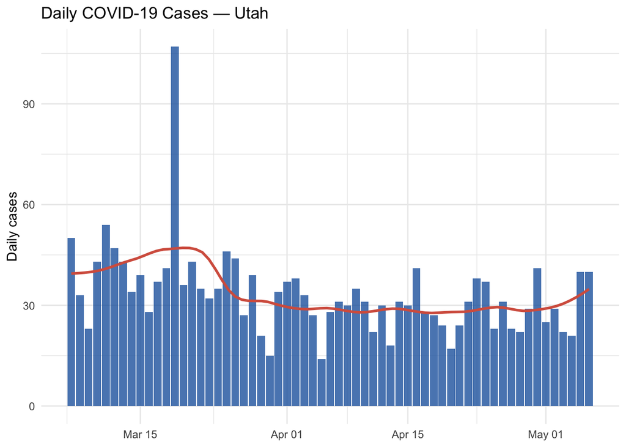

```r
p1 <- ggplot(covid_data, aes(x = Date, y = Daily.Cases)) +
  geom_col(fill = "#2166ac", alpha = 0.8) +
  geom_smooth(method = "loess", span = 0.35, se = FALSE, colour = "#d6604d") +
  scale_y_continuous(labels = scales::comma) +
  labs(title = "Daily COVID-19 Cases — Utah",
       x = NULL, y = "Daily cases") +   theme_minimal()
print(p1)
```

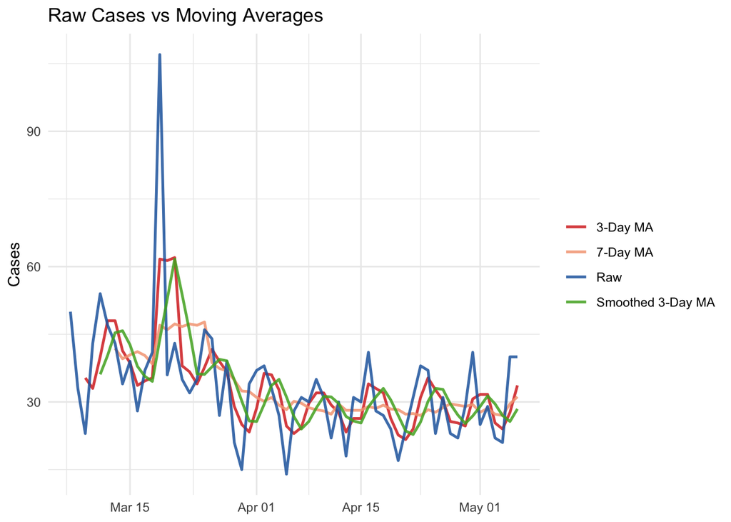

```r
p5 <- covid_data |>
  mutate(
    # recompute all averages from Daily.Cases directly
    ma3        = zoo::rollmean(Daily.Cases, k = 3, fill = NA, align = "right"),
    ma3_smooth = zoo::rollmean(ma3,         k = 3, fill = NA, align = "right"),
    roll7      = zoo::rollmean(Daily.Cases, k = 7, fill = NA, align = "right")
  ) |>
  tidyr::pivot_longer(
    cols      = c(Daily.Cases, ma3, ma3_smooth, roll7),
    names_to  = "Metric",
    values_to = "Value"
  ) |>
  mutate(Metric = dplyr::recode(Metric,
                                "Daily.Cases" = "Raw",
                                "ma3"         = "3-Day MA",
                                "ma3_smooth"  = "Smoothed 3-Day MA",
                                "roll7"       = "7-Day MA"
  )) |>
  ggplot(aes(x = Date, y = Value, colour = Metric)) +
  geom_line(linewidth = 0.9, alpha = 0.85, na.rm = TRUE) +
  scale_colour_manual(
    values = c(
      "Raw"              = "#2166ac",
      "3-Day MA"         = "#d73027",
      "Smoothed 3-Day MA"= "#4dac26",
      "7-Day MA"         = "#f4a582"
    )
  ) +
  labs(
    title = "Raw Cases vs Moving Averages",
    x     = NULL,
    y     = "Cases",
    colour = NULL
  ) +
  theme_minimal()

print(p5)
```

As Shown above, a 7 day raw scores were a little too noisy, so I also plotted a 3-Day avg plot and a 7 - Day Avg plot as well.

```r
dnames <- c(
  "0-4","5-9","10-14","15-19","20-24","25-29","30-34",
  "35-39","40-44","45-49","50-54","55-59","60-64",
  "65-69","70-74","75-79","80+"
)

mm_url <- paste0(
  "https://raw.githubusercontent.com/epistorm/Epistorm-Mix/",
  "05966ba49c7b49fb1cd902d6b98b3be0bb2785a8/matrices/M_matrix/",
  "Total-M-by5_80-matrix.csv"
)
mm_file <- file.path(tempdir(), "contact_matrix.csv")
download.file(mm_url, destfile = mm_file, quiet = TRUE)

mm_raw <- fread(mm_file)
if ("resp_age_by5_80" %in% names(mm_raw)) {
  mm_raw[, resp_age_by5_80 := NULL]
}
mm <- as.matrix(mm_raw)
dimnames(mm) <- list(dnames, dnames)

# row stochastic version
mm_stochastic <- mm / rowSums(mm)

cat(
  "\n===== MIXING MATRIX =====\n",
  "Dimensions:", nrow(mm), "x", ncol(mm), "\n",
  "Age group with most contacts:", dnames[which.max(rowSums(mm))], "\n",
  "Age group with least contacts:", dnames[which.min(rowSums(mm))], "\n",
  "Row-stochastic valid (rows sum to 1):", all(abs(rowSums(mm_stochastic) - 1) < 1e-9), "\n",
  "Row sums:\n", paste(names(round(rowSums(mm), 2)), round(rowSums(mm), 2), collapse = "\n "), "\n"
)
```

```
===== MIXING MATRIX =====
 Dimensions: 17 x 17
 Age group with most contacts: 15-19
 Age group with least contacts: 80+
 Row-stochastic valid (rows sum to 1): TRUE
 Row sums:
 0-4 6.91
 5-9 10.09
 10-14 8.69
 15-19 10.31
 20-24 7.74
 25-29 6.03
 30-34 8.22
 35-39 8.14
 40-44 7.71
 45-49 7.81
 50-54 7.44
 55-59 8.93
 60-64 5.24
 65-69 5.25
 70-74 4.49
 75-79 5.08
 80+ 3.75
```

The above results show patterns for contacts. The group 15-19 interacts the most, whereas 80+ interacts the least.

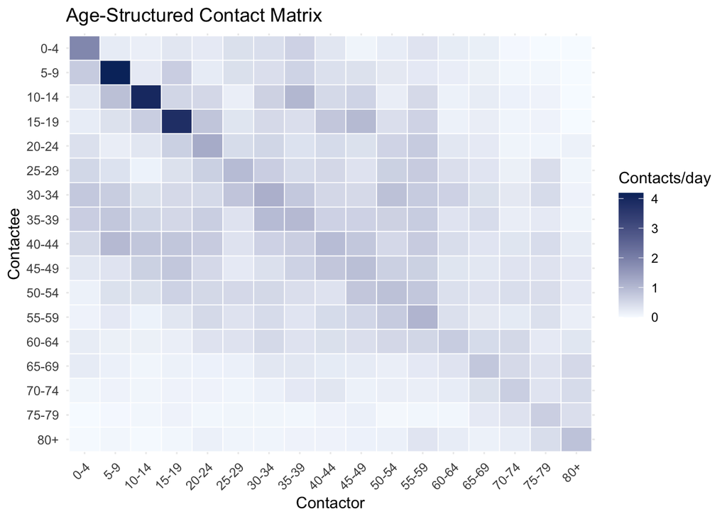

```r
p8 <- as.data.frame(as.table(mm)) |>
  rename(contactor = Var1, contactee = Var2, contacts = Freq) |>
  mutate(
    contactor = factor(contactor, levels = dnames),
    contactee = factor(contactee, levels = rev(dnames))
  ) |>
  ggplot(aes(x = contactor, y = contactee, fill = contacts)) +
  geom_tile(colour = "white", linewidth = 0.3) +
  scale_fill_gradient(low = "#f7fbff", high = "#08306b", name = "Contacts/day") +
  labs(title = "Age-Structured Contact Matrix",
       x = "Contactor", y = "Contactee") +
  theme_minimal() +
  theme(axis.text.x = element_text(angle = 45, hjust = 1))
print(p8)
```

Contact matrix shows contacts made by one group with the other.

Mostly, the trend shows every group makes most contact with people of same group.

Group 30-34 makes higher contacts with infants ( not too high suggesting a portion has no children ) , people from their age group and people of age 50-54, which makes sense, them being young parents.

Similarly, people of age 40 - 44 make contact with 5-9 and older children.

Graph below is just a graphical representation of what was displayed above as rows.

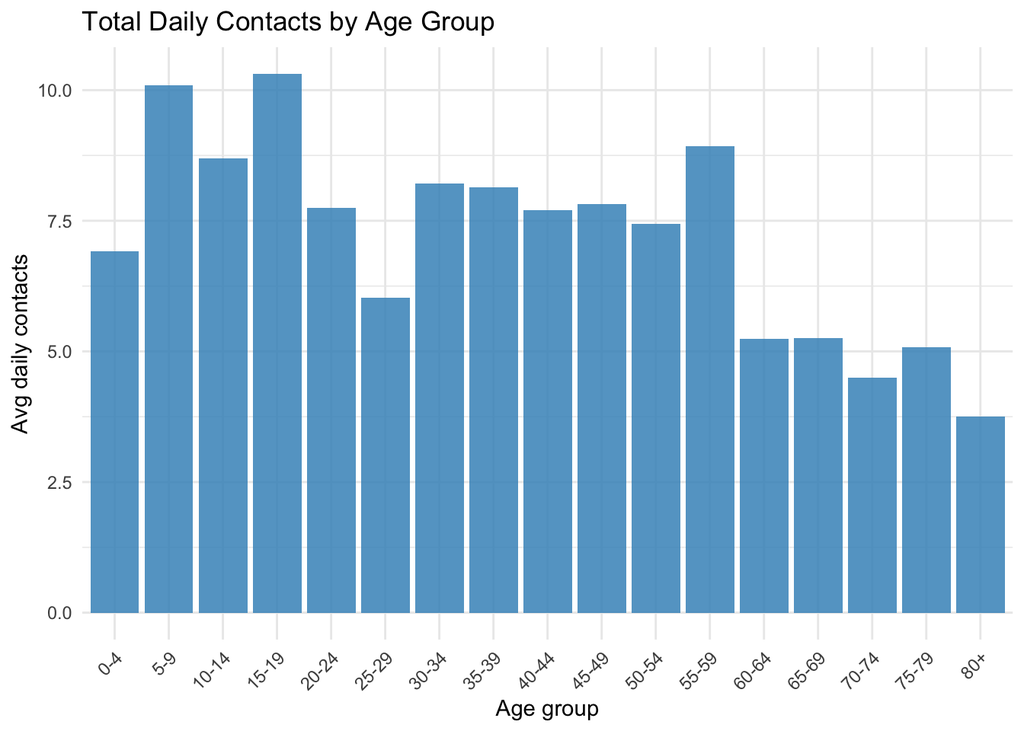

```r
p9 <- data.frame(
  age_group     = dnames,
  total_contacts = rowSums(mm)
) |>
  mutate(age_group = factor(age_group, levels = dnames)) |>
  ggplot(aes(x = age_group, y = total_contacts)) +
  geom_col(fill = "#4393c3", alpha = 0.85) +
  labs(title = "Total Daily Contacts by Age Group",
       x = "Age group", y = "Avg daily contacts") +
  theme_minimal() +
  theme(axis.text.x = element_text(angle = 45, hjust = 1))

print(p9)
```